# Predicting NBA Salary using Machine Learning Models

Anthony Clark

UCSB Fall 2023

# Introduction

## Objective

The objective of this project is to predict the salary of [National Basketball Association](https://en.wikipedia.org/wiki/National_Basketball_Association) (NBA) players based on their performance within the 2022-23 NBA season.

## Data Source

The data utilized in this project was obtained from the **NBA Player Salaries (2022-23 Season)** dataset, found at https://www.kaggle.com/datasets/jamiewelsh2/nba-player-salaries-2022-23-season/, which was scraped and compiled from [Basketball-Reference](https://www.basketball-reference.com/) and [HoopsHype](https://hoopshype.com/).

## Motivation

Within the NBA, there is one goal important to players, team staff, and ownership alike: winning an NBA championship (i.e., “winning a ring”). Basketball is a team sport; it is clear to anyone who has watched the NBA for several years that a championship is not something a player can win by themselves. Even players like LeBron James and Michael Jordan, who are typically considered to be the top two NBA players of all time, needed capable and skilled teammates in order to win championships.

Each team in the NBA has a soft salary cap, and receive escalating consequences as they further exceed this cap, including an intense luxury tax. To simplify, money is important to front offices in the NBA; therefore, the goal of this project is to determine whether teams are getting their money’s worth out of every player.

### Packages and Environment Setup

```r
knitr::opts_chunk$set(echo = TRUE,
                      message = FALSE,
                      warning = FALSE,
                      fig.align = "center")
library(dplyr)
library(tidyverse)
library(tidymodels)
library(ggplot2)
library(corrplot)
library(parsnip)
library(janitor)
library(scales)
library(viridis)
library(glmnet)
library(kknn)
library(ranger)
library(xgboost)
library(tune)
```

# Exploratory Data Analysis

## Loading and Tidying Raw Data

```r
# loading raw data
nba_raw <- read_csv("data/nba_2022-23_all_stats_with_salary.csv")
# cleaning names via janitor
nba_raw <- clean_names(nba_raw)
# display
head(nba_raw)
```

| x1 | player_name | salary | position | age | team | gp | gs | mp | fg | fga | fg_percent | x3p | x3pa | x3p_percent | x2p | x2pa | x2p_percent | e_fg_percent | ft | fta | ft_percent | orb | drb | trb | ast | stl | blk | tov | pf | … |
| --- | --- | --- | --- | --- | --- | --- | --- | --- | --- | --- | --- | --- | --- | --- | --- | --- | --- | --- | --- | --- | --- | --- | --- | --- | --- | --- | --- | --- | --- | --- |
| 0 | Stephen Curry | 48070014 | PG | 34 | GSW | 56 | 56 | 34.7 | 10.0 | 20.2 | 0.493 | 4.9 | 11.4 | 0.427 | 5.1 | 8.8 | 0.579 | 0.614 | 4.6 | 5.0 | 0.915 | 0.7 | 5.4 | 6.1 | 6.3 | 0.9 | 0.4 | 3.2 | 2.1 | … |
| 1 | John Wall | 47345760 | PG | 32 | LAC | 34 | 3 | 22.2 | 4.1 | 9.9 | 0.408 | 1.0 | 3.2 | 0.303 | 3.1 | 6.7 | 0.459 | 0.457 | 2.3 | 3.3 | 0.681 | 0.4 | 2.3 | 2.7 | 5.2 | 0.8 | 0.4 | 2.4 | 1.7 | … |
| 2 | Russell Westbrook | 47080179 | PG | 34 | LAL/LAC | 73 | 24 | 29.1 | 5.9 | 13.6 | 0.436 | 1.2 | 3.9 | 0.311 | 4.7 | 9.7 | 0.487 | 0.481 | 2.8 | 4.3 | 0.656 | 1.2 | 4.6 | 5.8 | 7.5 | 1.0 | 0.5 | 3.5 | 2.2 | … |
| 3 | LeBron James | 44474988 | PF | 38 | LAL | 55 | 54 | 35.5 | 11.1 | 22.2 | 0.500 | 2.2 | 6.9 | 0.321 | 8.9 | 15.3 | 0.580 | 0.549 | 4.6 | 5.9 | 0.768 | 1.2 | 7.1 | 8.3 | 6.8 | 0.9 | 0.6 | 3.2 | 1.6 | … |
| 4 | Kevin Durant | 44119845 | PF | 34 | BRK/PHO | 47 | 47 | 35.6 | 10.3 | 18.3 | 0.560 | 2.0 | 4.9 | 0.404 | 8.3 | 13.4 | 0.617 | 0.614 | 6.5 | 7.1 | 0.919 | 0.4 | 6.3 | 6.7 | 5.0 | 0.7 | 1.4 | 3.3 | 2.1 | … |
| 5 | Bradley Beal | 43279250 | SG | 29 | WAS | 50 | 50 | 33.5 | 8.9 | 17.6 | 0.506 | 1.6 | 4.4 | 0.365 | 7.3 | 13.2 | 0.552 | 0.551 | 3.8 | 4.6 | 0.842 | 0.8 | 3.1 | 3.9 | 5.4 | 0.9 | 0.7 | 2.9 | 2.1 | … |

```r
dim(nba_raw)
```

```
## [1] 467  52
```

There are 467 players (rows) and 52 variables (columns) in the data set.

The first column is a redundant index for the players; therefore, we will remove it:

```r
nba_raw = nba_raw[-1]
```

Some players have played for multiple teams over a single season, but player statistics are not separated by team; to address this, we will modify the `team` variable to only include the most recent team the player has played for, in order for that team’s front office to receive relevant information for managing their roster. Notably, player statistics such as minutes played and field goal attempts can certainly change when playing in an entirely different system, but their statistics should still ultimately provide an accurate representation of their value.

```r
# removing all except last 3 characters (last team abbreviation) from each team value
nba_raw$team <- substring(nba_raw$team, nchar(nba_raw$team) - 2)
```

We will follow a similar process for `position`; since some players are listed at multiple positions, we will select their primary listed position for simplicity.

```r
# keeping first two characters (first position) of each position value
nba_raw$position <- substring(nba_raw$position, 0, 2)
```

## Dealing with Missing Data

Initial observation reveals that several columns contain rows with missing data within our dataset:

```r
colSums(is.na(nba_raw))[which(colSums(is.na(nba_raw)) > 0)]
```

```
##   fg_percent  x3p_percent  x2p_percent e_fg_percent   ft_percent   ts_percent
##            1           13            4            1           23            1
##       x3p_ar         f_tr
##            1            1
```

We will remove the one individual player without a listed field goal percentage (this should not significantly affect the results of our dataset, and addresses the only NA value in this column)

```r
nba_raw <- drop_na(nba_raw, fg_percent)
colSums(is.na(nba_raw))[which(colSums(is.na(nba_raw)) > 0)]
```

```
## x3p_percent x2p_percent  ft_percent
##          12           3          22
```

There are only three predictors left with **NA** values: `x3p_percent`, `x2p_percent`, and `ft_percent`, with 12, 3, and 22 NA values, respectively. All of these missing values indicate that the relevant type of shot has not been attempted by the player. We will resolve these remaining missing values by substituting in a percentage of $0$ for all of the missing values; this will mean that a player who has attempted zero three-pointers will be treated effectively the same as a player who as attempted one three-pointer and missed, for example.

```r
# substituting 0 for NA percentage values
nba_raw$x2p_percent[is.na(nba_raw$x2p_percent)] <- 0
nba_raw$x3p_percent[is.na(nba_raw$x3p_percent)] <- 0
nba_raw$ft_percent[is.na(nba_raw$ft_percent)] <- 0

which(is.na(nba_raw))
```

```
## integer(0)
```

Now there is no missing data remaining in the dataset! We are ready to export and reread our modified data set.

```r
# exporting
write_csv(nba_raw, "data/nba_dataset.csv")

# loading in data
nba <- read_csv("data/nba_dataset.csv")

# changing position and team to factors
nba$position <- factor(nba$position,
                       # ordering positions
                       levels = c("PG", "SG", "SF", "PF", "C"))
nba$team <- factor(nba$team)

head(nba)
```

| player_name | salary | position | age | team | gp | gs | mp | fg | fga | fg_percent | x3p | x3pa | x3p_percent | x2p | x2pa | x2p_percent | e_fg_percent | ft | fta | ft_percent | orb | drb | trb | ast | stl | blk | tov | pf | pts | … |
| --- | --- | --- | --- | --- | --- | --- | --- | --- | --- | --- | --- | --- | --- | --- | --- | --- | --- | --- | --- | --- | --- | --- | --- | --- | --- | --- | --- | --- | --- | --- |
| Stephen Curry | 48070014 | PG | 34 | GSW | 56 | 56 | 34.7 | 10.0 | 20.2 | 0.493 | 4.9 | 11.4 | 0.427 | 5.1 | 8.8 | 0.579 | 0.614 | 4.6 | 5.0 | 0.915 | 0.7 | 5.4 | 6.1 | 6.3 | 0.9 | 0.4 | 3.2 | 2.1 | 29.4 | … |
| John Wall | 47345760 | PG | 32 | LAC | 34 | 3 | 22.2 | 4.1 | 9.9 | 0.408 | 1.0 | 3.2 | 0.303 | 3.1 | 6.7 | 0.459 | 0.457 | 2.3 | 3.3 | 0.681 | 0.4 | 2.3 | 2.7 | 5.2 | 0.8 | 0.4 | 2.4 | 1.7 | 11.4 | … |
| Russell Westbrook | 47080179 | PG | 34 | LAC | 73 | 24 | 29.1 | 5.9 | 13.6 | 0.436 | 1.2 | 3.9 | 0.311 | 4.7 | 9.7 | 0.487 | 0.481 | 2.8 | 4.3 | 0.656 | 1.2 | 4.6 | 5.8 | 7.5 | 1.0 | 0.5 | 3.5 | 2.2 | 15.9 | … |
| LeBron James | 44474988 | PF | 38 | LAL | 55 | 54 | 35.5 | 11.1 | 22.2 | 0.500 | 2.2 | 6.9 | 0.321 | 8.9 | 15.3 | 0.580 | 0.549 | 4.6 | 5.9 | 0.768 | 1.2 | 7.1 | 8.3 | 6.8 | 0.9 | 0.6 | 3.2 | 1.6 | 28.9 | … |
| Kevin Durant | 44119845 | PF | 34 | PHO | 47 | 47 | 35.6 | 10.3 | 18.3 | 0.560 | 2.0 | 4.9 | 0.404 | 8.3 | 13.4 | 0.617 | 0.614 | 6.5 | 7.1 | 0.919 | 0.4 | 6.3 | 6.7 | 5.0 | 0.7 | 1.4 | 3.3 | 2.1 | 29.1 | … |
| Bradley Beal | 43279250 | SG | 29 | WAS | 50 | 50 | 33.5 | 8.9 | 17.6 | 0.506 | 1.6 | 4.4 | 0.365 | 7.3 | 13.2 | 0.552 | 0.551 | 3.8 | 4.6 | 0.842 | 0.8 | 3.1 | 3.9 | 5.4 | 0.9 | 0.7 | 2.9 | 2.1 | 23.2 | … |

```r
dim(nba)
```

```
## [1] 466  51
```

## Visual EDA

It’s time to explore the relationships between our outcome variable `salary` and various predictors in the dataset, as well as the relationships these variables have with each other.

### Salary Distribution

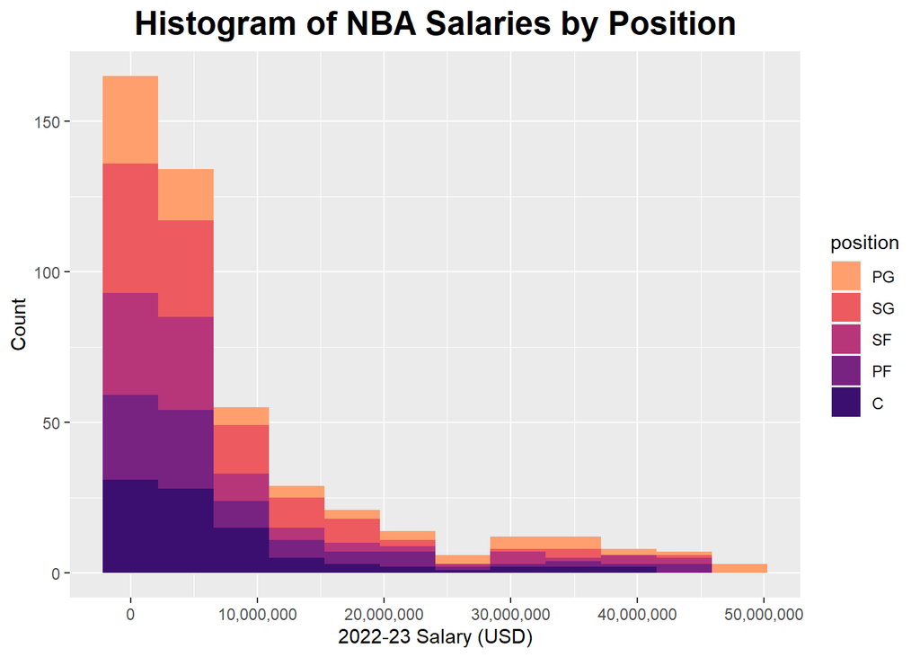

```r
ggplot(nba, aes(x = salary, fill = position)) + geom_histogram(bins = 12) +
  scale_x_continuous(labels = comma) +
  scale_fill_manual(values = pos_col) +
  theme(plot.title = element_text(size = 18, face = "bold", hjust = 0.5)) + labs(
      x = "2022-23 Salary (USD)",
      y = "Count",
      title = "Histogram of NBA Salaries by Position"
    )
```

The distribution of NBA salaries appears to be significantly right-skewed and unimodal; this is logically sound, as the majority of NBA players are “bench players” (not in the typical starting 5), and are often paid less than the best players on the team at each position (the “starters”). As shown by the figure, high salaries are seemingly reserved for players that are determined to be elite in their position. However, there are many statistically intangible factors that go into contract negotiation; let’s next observe whether correlation can be seen between player performance and salary.

### Salary against Points per Game

We will begin with a graph of salary against points per game (`pts`):

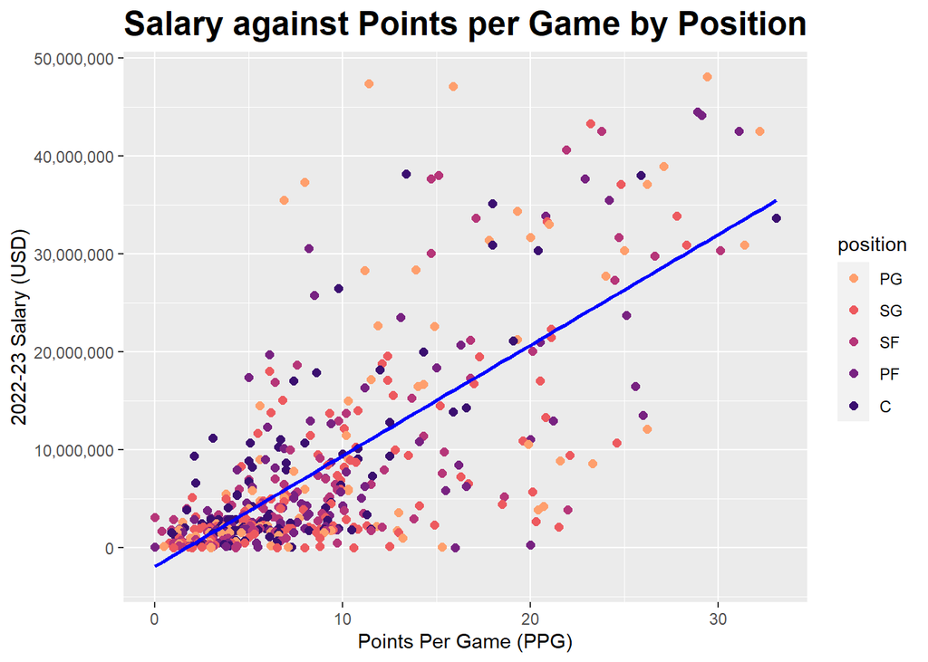

```r
ggplot(nba, aes(x = pts, y = salary, col = position)) + geom_point(size = 2) +
  scale_y_continuous(labels = comma) +
  theme(plot.title = element_text(size = 18, face = "bold", hjust = 0.5)) +
  scale_color_manual(values = pos_col) + labs(
      x = "Points Per Game (PPG)",
      y = "2022-23 Salary (USD)",
      title = "Salary against Points per Game by Position"
  ) + geom_smooth(method = "lm", fill = NA, col="blue")
```

As we can see, there appears to be a positive relationship between points per game and salary. Let’s create a correlation matrix and a plot to observe possible correlation between salary and other predictor variables, as well as correlation between predictors.

### Correlation Plot

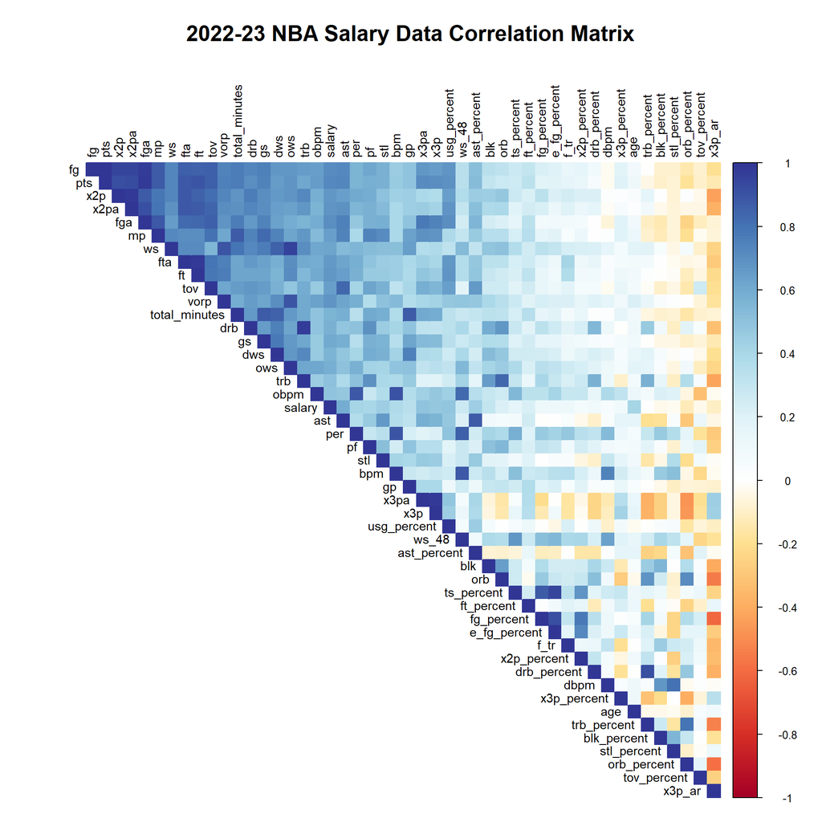

```r
nba %>%
    select(is.numeric) %>%
    cor() %>%
    corrplot(type = "upper",
             method = "color",
             order = "FPC",
             col = COL2("RdYlBu"),
             diag = T,
             tl.cex = 0.9,
             tl.col = "black",
             title = "2022-23 NBA Salary Data Correlation Matrix",
             mar=c(0,0,4,0),
             cex.main = 1.6)
```

Our correlation plot reveals that several of the predictors positively impact the outcome, `salary`. Statistics such as points (`pts`), rebounds (`trb`), and `total_minutes` are all positively correlated with player salary. One interesting detail is that the percentage of total shots a player attempts that are taken from three-point range (`x3p_ar`) is negatively correlated with several other predictors, as well as having a slight negative correlation with `salary`. This carries the implication that a player who attempts a significant number of their total shot attempts from three-point range is generally a bad value investment for front offices.

Overall, it seems from our correlation plot (as well as our plot of salary against points per game) that modeling salary via these predictors is a reasonable approach for salary prediction. Let’s now begin preparing our models for training.

# Model Preparation

## Splitting Data (with Stratification)

We will first split the dataset into a training and testing dataset with a 70%/30% training/testing split. This is done to ensure that our models perform similarly on the unknown data (testing set) after they are trained using the training set. In order to replicate our results, we set a random seed before splitting the data. Furthermore, we are stratifying the data on `salary` (our outcome variable) in order to ensure that the population of NBA salaries is properly represented in both the training and testing data.

```r
# setting seed for replication
set.seed(33)

# Splitting data into train/test set
nba_split <- initial_split(nba,
                           # 70/30 split
                           prop = 0.7,
                           # stratifying on salary
                           strata = salary)

nba_train <- training(nba_split)
nba_test <- testing(nba_split)

# verifying 70/30 split
train_count = as.integer(count(nba_train))
test_count = as.integer(count(nba_test))
TrainingProportion = train_count/as.integer(count(nba))
TestingProportion = test_count/as.integer(count(nba))
v_df <- data.frame("Training" = c(train_count, TrainingProportion),
             "Testing" = c(test_count, TestingProportion))
rownames(v_df) = c("Count", "Proportion")
v_df
```

|  | Training | Testing |
| --- | --- | --- |
| Count | 324.000000 | 142.000000 |
| Proportion | 0.695279 | 0.304721 |

As shown by the dataframe, the split was roughly 70/30, and each set has a reasonable number of observations for modeling (n > 30).

## Creating Recipe

We are constructing a single recipe to use for all of the upcoming models; therefore, we are including nearly all of the predictors, with the exception of `player_name` and `team`. These player and team variables serve primarily as identifiers within the context of our modeling; since we are focused on modeling salary based on players’ statistical performance, we are not concerned with using these predictors in our recipe.

We are concerned, however, with the remaining categorical variable; `position`. Players in differing positions impact the game of basketball differently; for example, point guards tending to get more assists due to their traditional ball handling and passing role, while centers tend to obtain more rebounds due to their height advantage (there are, of course, exceptions to every traditional role; look at Nikola Jokic’s passing as an example).

```r
# recipe creation
recipe_nba <- recipe(
  salary ~ ., data = nba_train) %>%
  # removing player_name and team
  step_rm(player_name, team) %>%
  # dummy variable creation
  step_dummy(all_nominal_predictors(), one_hot = T) %>%
  # centering and scaling (normalization)
  step_normalize(all_predictors())
```

```r
#prep/bake check
recipe_nba %>%
  prep() %>%
  bake(nba_train)
```

| age | gp | gs | mp | fg | fga | fg_percent | x3p | x3pa | x3p_percent | x2p | x2pa | x2p_percent | e_fg_percent | ft | fta | ft_percent | orb | drb | trb | ast | stl | blk | tov | pf | pts | total_minutes | per | ts_percent | x3p_ar | … |
| --- | --- | --- | --- | --- | --- | --- | --- | --- | --- | --- | --- | --- | --- | --- | --- | --- | --- | --- | --- | --- | --- | --- | --- | --- | --- | --- | --- | --- | --- | --- |
| -0.17792935 | 1.11907576 | -0.073969782 | 0.348742975 | -0.05965582 | 0.041972285 | -0.233993410 | -0.12806893 | -0.02347609 | -0.082414862 | 0.03376363 | 0.07581473 | -0.048632761 | -0.354139870 | 0.21594318 | 0.22149801 | 0.357039689 | -0.34748174 | 0.19834880 | 0.045133131 | 0.18776510 | 0.18527769 | -0.47122740 | 0.22647035 | -0.257446772 | -0.007995841 | 0.786892975 | -0.305813730 | -0.187260950 | -0.114817142 | … |
| -0.65046304 | 0.80292923 | -0.766003187 | -0.932916169 | -0.62458027 | -0.820213441 | 1.197976651 | -1.12128438 | -1.19034434 | -1.083939536 | -0.27294895 | -0.40307005 | 0.586840946 | 0.618399686 | -0.52771233 | -0.59926375 | 0.154952985 | 1.08488573 | -0.26691824 | 0.134298584 | -0.88943031 | 0.18527769 | 0.93206007 | -0.49883173 | 0.122854538 | -0.705479234 | -0.438918039 | 0.996161436 | 0.593310265 | -1.785963257 | … |
| -0.65046304 | 0.76341092 | 1.528633891 | 0.958564665 | 0.66667561 | 0.727801840 | -0.001298275 | -0.34878348 | -0.23956280 | -0.214969598 | 1.05613889 | 1.20260244 | -0.096464116 | -0.363314771 | 0.46382835 | 0.32409324 | 0.683134144 | -0.06100824 | 0.08203204 | 0.045133131 | 2.29086091 | 1.67362405 | -0.75188489 | 0.58912139 | -0.384213875 | 0.532909647 | 1.013851234 | 0.462017778 | -0.235444358 | -0.914884262 | … |
| -0.41419620 | -1.56816970 | -0.838848808 | -1.108627503 | -0.62458027 | -0.820213441 | 1.197976651 | -0.79021256 | -0.88782294 | 0.845468292 | -0.47742400 | -0.60025790 | 0.887495173 | 1.095494563 | -0.52771233 | -0.59926375 | 0.559126393 | 0.08222850 | -0.55771014 | -0.400694137 | -0.99202035 | -1.05501095 | -0.47122740 | -0.86148277 | 0.122854538 | -0.677010524 | -1.233271946 | 0.578861703 | 1.123327756 | -0.697114514 | … |
| -0.88672988 | -1.37057813 | -0.838848808 | -1.553073820 | -1.27020821 | -1.133735524 | -2.766790457 | -1.12128438 | -1.10390966 | -2.313752923 | -1.09084916 | -0.91012452 | -2.269374212 | -3.473606371 | -0.89954009 | -0.95834702 | -3.266742343 | -0.77719198 | -1.43008584 | -1.336931398 | -0.83813529 | -1.05501095 | -0.75188489 | -0.74059909 | -1.271583599 | -1.246384722 | -1.251003060 | -3.043299975 | -3.935930117 | -0.976427887 | … |
| -0.65046304 | -0.69876676 | -0.766003187 | -1.180979229 | -0.82633900 | -0.937784222 | 0.544640311 | -0.90056984 | -0.97425763 | -0.376980942 | -0.63078029 | -0.71293667 | 0.593673996 | 0.223878923 | -0.77559750 | -0.75315658 | -0.763622942 | 0.08222850 | -1.19745232 | -0.891104131 | -0.94072533 | -1.30306868 | -0.47122740 | -0.98236645 | -1.144816495 | -0.890525848 | -1.019316503 | -0.372581687 | -0.013800680 | -0.725519264 | … |
| -0.88672988 | -1.68672465 | -0.802425997 | -0.736532913 | -0.34211805 | -0.369525448 | 0.088199854 | 0.20300288 | -0.23956280 | 1.368323086 | -0.52854276 | -0.37490036 | -0.520113254 | 0.453251460 | -0.89954009 | -0.95834702 | -3.266742343 | -0.92042872 | -1.25561070 | -1.247765944 | -0.42777513 | 0.43333541 | -1.03254238 | -0.37794805 | -1.144816495 | -0.420792135 | -1.240364391 | -0.038741901 | 0.188569635 | 0.150293856 | … |
| -0.17792935 | 1.23763071 | -0.547466322 | -0.395446205 | -0.42282154 | -0.428310839 | -0.037097527 | 0.86514651 | 0.58156671 | 0.764462620 | -0.93749287 | -0.99463360 | 0.928493477 | 0.939521238 | -0.77559750 | -0.85575180 | -0.024169320 | -0.63395523 | -0.32507662 | -0.400694137 | -0.63295521 | -0.55889550 | -0.19056990 | -0.86148277 | -0.637748082 | -0.392323425 | 0.193491694 | -0.088817869 | 0.728223808 | 2.081816845 | … |
| -0.88672988 | -0.50117518 | -0.693157565 | -0.953588091 | -0.94739424 | -0.898593962 | -0.645684803 | -0.56949802 | -0.58530154 | -0.038229950 | -0.93749287 | -0.91012452 | -0.137462419 | -0.464238688 | -0.71362621 | -0.75315658 | 0.099838430 | -0.34748174 | -0.90666042 | -0.801938677 | -0.78684027 | -0.55889550 | -0.47122740 | -0.86148277 | -0.764515185 | -0.904760203 | -0.876285517 | -0.806573409 | -0.543818171 | 0.874614977 | … |
| -0.88672988 | -0.77780339 | -0.838848808 | -1.470386133 | -1.14915298 | -1.153330654 | -0.484588171 | -0.90056984 | -0.93104028 | -0.561084743 | -1.03973039 | -1.05097298 | 0.716668908 | -0.510113195 | -0.89954009 | -0.90704941 | -0.970302525 | -0.92042872 | -1.13929394 | -1.158600491 | -0.78684027 | -1.05501095 | -1.03254238 | -1.10325013 | -1.398350702 | -1.132509882 | -1.136341856 | -0.923417334 | -0.804008576 | 0.765730103 | … |

[output cut: 314 more lines]

## K-Fold Cross-Validation

As a final resampling procedure before continuing on with model building, we will apply k-fold cross validation to our training dataset, with a total of 10 folds. We stratify these folds on our outcome variable, `salary`, in order to ensure a balanced representation of salary within each of the folds.

```r
# folding training dataset
nba_folds <- vfold_cv(nba_train, v = 10, strata = "salary")
```

# Model Construction

## Model Fitting

We will break down our model construction process into steps, while including a chunk of code for each of them as necessary.

1. Set up the model by specifying the model type, the engine, and the mode (in our case, all of the models will be regression models):

```r
# Linear Regression
lm_mod <- linear_reg() %>%
  set_engine("lm")

# Elastic Net
en_mod <- linear_reg(
  # tuning both parameters to specify elastic net
  penalty = tune(),
  mixture = tune()
) %>%
  set_engine("glmnet") %>%
  set_mode("regression")

# K-Nearest Neighbors (KNN)
knn_mod <- nearest_neighbor(
  # tuning number of neighbors
  neighbors = tune()
) %>%
  set_engine("kknn") %>%
  set_mode("regression")

# Random Forest
rf_mod <- rand_forest(
  # tuning mtry (predictor count)
  mtry = tune(),
  # tuning number of trees
  trees = tune(),
  # tuning min_n (minimum values in a node)
  min_n = tune()
) %>%
  set_engine("ranger",
             # importance specified to store variable importance
             importance = "impurity") %>%
  set_mode("regression")

# Boosted Tree
boost_mod <- boost_tree(
  # tuning mtry (learning rate chosen to tune rather than min_n to reduce grid size)
  mtry = tune(),
  # tuning trees
  trees = tune(),
  # tuning learning rate
  learn_rate = tune()
) %>%
  set_engine("xgboost") %>%
  set_mode("regression")
```

2. Set up model workflows and add the model and recipe:

```r
# Linear Regression
lm_wf <- workflow() %>%
  add_model(lm_mod) %>%
  add_recipe(recipe_nba)

# Elastic Net
en_wf <- workflow() %>%
  add_model(en_mod) %>%
  add_recipe(recipe_nba)

# K-Nearest Neighbors (KNN)
knn_wf <- workflow() %>%
  add_model(knn_mod) %>%
  add_recipe(recipe_nba)

# Random Forest
rf_wf <- workflow() %>%
  add_model(rf_mod) %>%
  add_recipe(recipe_nba)

# Boosted Tree
boost_wf <- workflow() %>%
  add_model(boost_mod) %>%
  add_recipe(recipe_nba)
```

3. Create a tuning grid (when applicable) to specify parameter ranges and how many levels of each parameter:

```r
# Linear Regression
# No parameters to be tuned; no grid

# Elastic Net
en_grid <- grid_regular(
  penalty(range = c(-5, 5)),
  mixture(range = c(0, 1)),
  levels = 10
)

# K-Nearest Neighbors (KNN)
knn_grid <- grid_regular(
  neighbors(range = c(1, 20)),
  levels = 10
)

# Random Forest
rf_grid <- grid_regular(
  # mtry maximum value less than total number of predictors
  mtry(range = c(1, 45)),
  trees(range = c(200, 1200)),
  min_n(range = c(5, 30)),
  levels = 10
)

# Boosted Tree
boost_grid <- grid_regular(
  mtry(range = c(1, 45)),
  trees(range = c(200, 1200)),
  learn_rate(range = c(0.0001, 0.1),
             trans = identity_trans()),
  levels = 10
)
```

4. Tune the models (when applicable), specifying workflow, folds, and relevant tuning grid:

```r
# Linear Regression
# No tuning, but we will fit the model here anyway
lm_fit <- fit_resamples(lm_wf, resamples = nba_folds)

# Elastic Net
en_tune <- tune_grid(
  en_wf,
  resamples = nba_folds,
  grid = en_grid
)

# K-Nearest Neighbors (KNN)
knn_tune <- tune_grid(
  knn_wf,
  resamples = nba_folds,
  grid = knn_grid
)

# Random Forest
rf_tune <- tune_grid(
  rf_wf,
  resamples = nba_folds,
  grid = rf_grid
)

# Boosted Tree
boost_tune <- tune_grid(
  boost_wf,
  resamples = nba_folds,
  grid = boost_grid
)
```

5. Save the tuned models:

```r
# Saving models in order to prevent having to spend significant time processing redundant tuning

# Linear Regression
save(lm_fit, file = "data/trained_models/lm_fit.rda", compress = F)

# Elastic Net
save(en_tune, file = "data/trained_models/elasticnet.rda", compress = F)

# K-Nearest Neighbors (KNN)
save(knn_tune, file = "data/trained_models/knn.rda", compress = F)

# Random Forest
save(rf_tune, file = "data/trained_models_2/rf.rda", compress = F)

# Boosted Tree
save(boost_tune, file = "data/trained_models_2/boost.rda", compress = F)
```

6. Load the tuned models:

```r
# loading saved tuned models
load("data/trained_models/lm_fit.rda")       # lm_fit
load("data/trained_models/elasticnet.rda")   # en_tune
load("data/trained_models/knn.rda")          # knn_tune
load("data/trained_models_2/rf.rda")           # rf_tune
load("data/trained_models_2/boost.rda")        # boost_tune
```

7. Collect metrics for each model based on best RMSE average:

```r
# collecting metrics of best tuned model
best_lm <- show_best(lm_fit, metric = "rmse")
best_en <- show_best(en_tune, metric = "rmse", n = 1)
best_knn <- show_best(knn_tune, metric = "rmse", n = 1)
best_rf <- show_best(rf_tune, metric = "rmse", n = 1)
best_boost <- show_best(boost_tune, metric = "rmse", n = 1)

best_lm_rmse <- best_lm$mean
best_en_rmse <- best_en$mean
best_knn_rmse <- best_knn$mean
best_rf_rmse <- best_rf$mean
best_boost_rmse <- best_boost$mean
```

# Model Results and Selection Performance

We will now compare the RMSE values of each of our models to see which performed the best overall.

```r
# tibble of model types and their best RMSE
model_comparison <- tibble(
  "Model" = c("Linear Regression", "Elastic Net", "K-Nearest Neighbors", "Random Forest", "Boosted Tree"),
  "RMSE" = c(best_lm_rmse, best_en_rmse, best_knn_rmse, best_rf_rmse, best_boost_rmse)
)
# sort by RMSE
model_comparison <- model_comparison %>% arrange(RMSE)
model_comparison
```

| Model | RMSE |
| --- | --- |
| Boosted Tree | 5376808 |
| Random Forest | 5613329 |
| Elastic Net | 6299499 |
| Linear Regression | 6875465 |
| K-Nearest Neighbors | 6892202 |

As we can see from the table, the **Boosted Tree** model performed the best on our cross-validated training data (and therefore has the lowest RMSE); however, the **Random Forest** model is not far off in performance. We will try fitting both the Boosted Tree and Random Forest models to our testing set, as they both appear to be marginally better than our remaining regression models. Let’s visualize the results of these two models before continuing.

## Boosted Tree plot

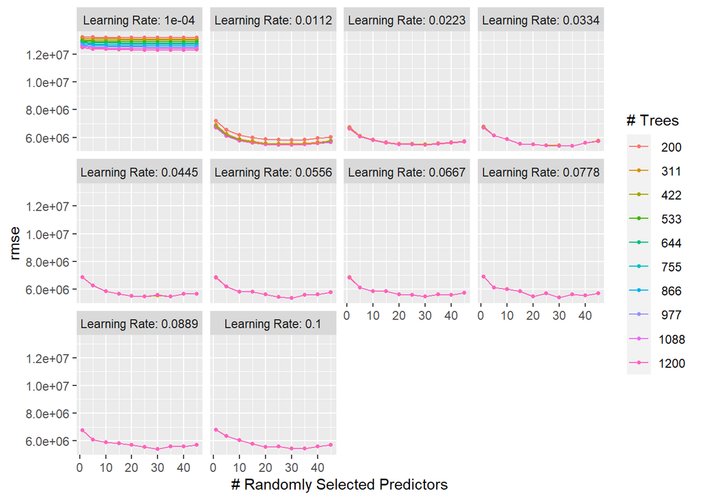

```r
autoplot(boost_tune, metric = "rmse")
```

## Random Forest Plot

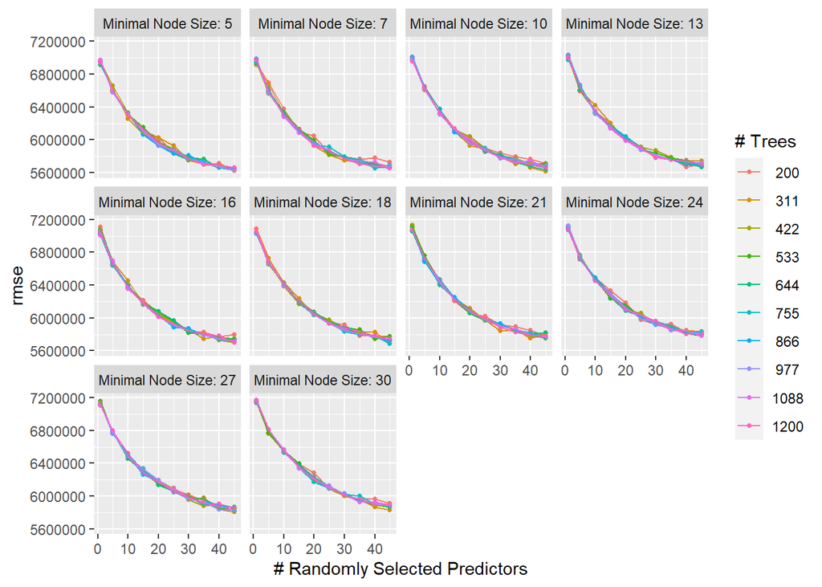

```r
autoplot(rf_tune, metric = "rmse")
```

The autoplot of the Random Forest model reveals that the number of trees does not appear to significantly impact model performance; the same seems to apply for the minimal node size. However, the number of selected predictors does appear to significantly impact RMSE, with a fairly general trend of increased performance when the number of selected predictors increases. However, when looking at the graph in detail, there are some exceptions at the highest level of predictors.

# Model Performance on the Testing Set